# Telecom: Identifying Ineffective Operators

Here’s a description of the files in the google drive link:

- Telecom Presentation - Neta Hayat.pdf - PDF presentation.
- URL - Telecom Dashboard - Neta Hayat Final - Includes a link to the dashboard Tableau Public’s Server

And here's the **link:**

https://drive.google.com/drive/folders/1oJmEdXONqCXIYkMOZB6IwGsgDvttqy6B?usp=sharing

## Description:

The virtual telephony service CallMeMaybe is developing a new function that will give supervisors information on the least effective operators. An operator is considered ineffective if they have a large number of missed incoming calls (internal and external) and a long waiting time for incoming calls. Moreover, if an operator is supposed to make outgoing calls, a small number of them is also a sign of ineffectiveness.

The datasets contain data on the use of the virtual telephony service CallMeMaybe. Its clients are organizations that need to distribute large numbers of incoming calls among various operators, or make outgoing calls through their operators. Operators can also make internal calls to communicate with one another. These calls go through CallMeMaybe's network.

# Main goal

- Analysing the data, identifying ineffective operators and provide general conclusions and recommendations about the clients operators.

### Tables Of Contents

- Step 1: Downloading and exploring the datasets
- Step 2: Preprocessing the data
- What defines an ineffective operator?
- Step 3: EDA - Carring out exploratory data analysis
- Missed Incoming Calls
- Waiting time
- Number of outgoing calls
- Building a fuction to rate operators' effectivness
- Step 4: Testing Hypotheses
- Final Conclusion and recommendation

## Step 1: Downloading and exploring the datasets

Go back to the Table of Contents

**Importing libraries**

```python
!pip install --upgrade seaborn
```

```python
import pandas as pd
import numpy as np
import matplotlib.pyplot as plt
import scipy.stats as stats
import seaborn as sns
import plotly.express as px
import matplotlib.ticker as mtick
from plotly import graph_objects as go
from datetime import datetime
from pandas.plotting import register_matplotlib_converters
register_matplotlib_converters()
from scipy import stats as st
import numpy as np
import math as mth
import math
from scipy import stats
import plotly.figure_factory as ff
```

```python
data = pd.read_csv('/datasets/telecom_dataset_us.csv')
data.sample()
data.shape
data.tail()
data.head()
```

|  | user_id | date | direction | internal | operator_id | is_missed_call | calls_count | call_duration | total_call_duration |
| --- | --- | --- | --- | --- | --- | --- | --- | --- | --- |
| 0 | 166377 | 2019-08-04 00:00:00+03:00 | in | False | NaN | True | 2 | 0 | 4 |
| 1 | 166377 | 2019-08-05 00:00:00+03:00 | out | True | 880022.0 | True | 3 | 0 | 5 |
| 2 | 166377 | 2019-08-05 00:00:00+03:00 | out | True | 880020.0 | True | 1 | 0 | 1 |
| 3 | 166377 | 2019-08-05 00:00:00+03:00 | out | True | 880020.0 | False | 1 | 10 | 18 |
| 4 | 166377 | 2019-08-05 00:00:00+03:00 | out | False | 880022.0 | True | 3 | 0 | 25 |

**As we can see, each row represents a call - client account ID, the date the statistics were retrieved, call direction, whether the call was internal, operator identifier, whether the call was missed, number of calls, call duration including and excluding waiting time)**

```python
data.info(memory_usage='deep')
```

```
<class 'pandas.core.frame.DataFrame'>
RangeIndex: 53902 entries, 0 to 53901
Data columns (total 9 columns):
user_id                53902 non-null int64
date                   53902 non-null object
direction              53902 non-null object
internal               53785 non-null object
operator_id            45730 non-null float64
is_missed_call         53902 non-null bool
calls_count            53902 non-null int64
call_duration          53902 non-null int64
total_call_duration    53902 non-null int64
dtypes: bool(1), float64(1), int64(4), object(3)
memory usage: 11.1 MB
```

- By using the info method, we can see that there are 9 columns and 53902 rows.
- There are missing values in the internal and operator_id columns.
- Changing necessary data types to 'date' column (to datetime type), 'operator_id' (to int type)
- The memory usage is quiet small and therefore, we don't need to optimize the data.

**Searching for duplicated rows**

```python
duplicated_rows = data.duplicated().sum()
print('The number of duplicated rows is:', duplicated_rows)
```

```
The number of duplicated rows is: 4900
```

```python
data.describe()
```

|  | user_id | operator_id | calls_count | call_duration | total_call_duration |
| --- | --- | --- | --- | --- | --- |
| count | 53902.000000 | 45730.000000 | 53902.000000 | 53902.000000 | 53902.000000 |
| mean | 167295.344477 | 916535.993002 | 16.451245 | 866.684427 | 1157.133297 |
| std | 598.883775 | 21254.123136 | 62.917170 | 3731.791202 | 4403.468763 |
| min | 166377.000000 | 879896.000000 | 1.000000 | 0.000000 | 0.000000 |
| 25% | 166782.000000 | 900788.000000 | 1.000000 | 0.000000 | 47.000000 |
| 50% | 167162.000000 | 913938.000000 | 4.000000 | 38.000000 | 210.000000 |
| 75% | 167819.000000 | 937708.000000 | 12.000000 | 572.000000 | 902.000000 |
| max | 168606.000000 | 973286.000000 | 4817.000000 | 144395.000000 | 166155.000000 |

- By using the describe method, We can see:
- 'calls_count':
  - The minimum nuber of calls is 1 and the maximum is 4817.
  - Based on the mean value ,the average number of calls is 16, however we can see that the median value is 4. We can assume that there are outliers in the distribution of this feature, which means there are clients that have a bigger number of calls that affects the mean value. For example the max value of calls is 4817, this value has a direct affect on the mean value in comparison to the median. we can also see that from the std value which is pretty high - 62.9. we would have to deal with these outliers in order to get more accurate results.
- 'call_duration':
  - The minimum duration time is 0 and the maximum is 144395. I believe the duration represented in seconds.
  - Here as well, we can see that the mean value (866.6) is significantly higher than the median 38. and the std value is ver high, that shows us that there are outliers, call durations that lasted extremely longer than the median time. These outliers affect the distribution of this column and are the reason for the difference between the mean and median values, and we will have to deal with them as well in order to get accurate results.
- 'total_call_duration':
  - The minimum duration time inclusing waiting time is 0 and the maximum is 166155. I believe the duration here is represented in seconds as well.
  - Just like the 'call duration' column, we can see that the mean is higher than the median value as well. There are outliers after the 50% (Q2) that affect the mean value. these ouliers here as well will have to be treated to get an accurate result.

**Exploring columns individually to look for unique/missing/duplicated/abnormal values**

*'user_id'*

```python
unique_clients = data['user_id'].unique()
print('The number of unique clients is',len(unique_clients))
```

```
The number of unique clients is 307
```

```python
data['user_id'].value_counts()
```

```
168187    2580
166658    2107
167497    1405
167626    1311
166916    1308
          ...
168013       1
167981       1
166584       1
166554       1
168578       1
Name: user_id, Length: 307, dtype: int64
```

- The client with the most calls is 168187.

*'date'*

```python
print(data['date'].min())
print(data['date'].max())
```

```
2019-08-02 00:00:00+03:00
2019-11-28 00:00:00+03:00
```

- The period of time where the statistics were retrieved is 02.08.2019 - 28.11.2019

*'direction'*

```python
data['direction'].value_counts()
```

```
out    31917
in     21985
Name: direction, dtype: int64
```

- There were more outgoing calls (31917) than incoming calls (21985).

*'internal'*

```python
data['internal'].value_counts()
```

```
False    47621
True      6164
Name: internal, dtype: int64
```

- There were 6164 calls between operators, compare to 47621 calls that were costumers operator calls.

*'operator_id'*

```python
unique_operators = data['operator_id'].unique()
print('The number of unique operators is',len(unique_operators))
```

```
The number of unique operators is 1093
```

*'is_missed_call'*

```python
data['is_missed_call'].value_counts()
```

```
False    30334
True     23568
Name: is_missed_call, dtype: int64
```

- Out of 53902 calls, 23568 were missed calls (43% of all calls!).

*'calls_count'*

```python
data['calls_count'].value_counts()
```

```
1       14321
2        7015
3        4483
4        3342
5        2454
        ...
632         1
664         1
888         1
1432        1
1375        1
Name: calls_count, Length: 502, dtype: int64
```

- Most number of unique calls is 1.

*'call_duration'*

```python
data['call_duration'].value_counts()
```

```
0       23263
1         200
7         144
15        126
13        125
        ...
2607        1
8053        1
3927        1
1878        1
6395        1
Name: call_duration, Length: 5373, dtype: int64
```

- Almost half of the calls have 0 duration, which means there were missed calls.

*'total_call_duration'*

```python
data['total_call_duration'].value_counts()
```

```
0         1320
2          850
1          527
4          461
6          380
          ...
3313         1
9428         1
5298         1
78998        1
124787       1
Name: total_call_duration, Length: 6040, dtype: int64
```

- 1320 of the calls have 0 duration, which means there were missed calls.

**Exploring the whole dataset to get a general information**

**Second dataset - telecom_clients_us.csv**

```python
data1 = pd.read_csv('/datasets/telecom_clients_us.csv')
data1.sample()
data1.shape
data1.tail()
data1.head()
```

|  | user_id | tariff_plan | date_start |
| --- | --- | --- | --- |
| 0 | 166713 | A | 2019-08-15 |
| 1 | 166901 | A | 2019-08-23 |
| 2 | 168527 | A | 2019-10-29 |
| 3 | 167097 | A | 2019-09-01 |
| 4 | 168193 | A | 2019-10-16 |

**As we can see, each row represents a client account ID, his plan and the date he first registered**

```python
data1.info(memory_usage='deep')
```

```
<class 'pandas.core.frame.DataFrame'>
RangeIndex: 732 entries, 0 to 731
Data columns (total 3 columns):
user_id        732 non-null int64
tariff_plan    732 non-null object
date_start     732 non-null object
dtypes: int64(1), object(2)
memory usage: 95.2 KB
```

- By using the info method, we can see that there are 3 columns and 732 rows.
- There are no missing values.
- Changing necessary data types to 'date_start' column (to datetime type).
- The memory usage is quiet small and therefore, we don't need to optimize the data.

**Searching for duplicated rows**

```python
duplicated_rows1 = data1.duplicated().sum()
print('The number of duplicated rows is:', duplicated_rows1)
```

```
The number of duplicated rows is: 0
```

- There are no duplicated rows in this dataset.

**Exploring columns individually to look for unique/missing/duplicated/abnormal values**

*'user_id'*

```python
unique_clients1 = data1['user_id'].unique()
print('The number of unique clients is',len(unique_clients1))
```

```
The number of unique clients is 732
```

*'tariff_plan'*

```python
data1['tariff_plan'].value_counts()
```

```
C    395
B    261
A     76
Name: tariff_plan, dtype: int64
```

- There are 3 types of plans - A,B,C.
- The most popular one is C.

*'date_start'*

```python
print(data1['date_start'].min())
print(data1['date_start'].max())
```

```
2019-08-01
2019-10-31
```

- The earliest date a client has registered is 01.08.2019.
- The last registration was in 31.10.2019.

### Conclusion - Step 1: Downloading and exploring the datasets:

**telecom_dataset_us.csv:**

- There are 9 columns and 53902 rows.
- Each row represents a call - client account ID, the date the statistics were retrieved, call direction, whether the call was internal, operator identifier, whether the call was missed, number of calls, call duration including and excluding waiting time)
- There are missing values in the 'internal' and 'operator_id' columns.
- The number of duplicated rows is: 4900
- Changing necessary data types to 'date' column (to datetime type), 'operator_id' (to int type)
- The memory usage is quiet small and therefore, we don't need to optimize the data.
- 'calls_count':
  - The minimum number of calls is 1 and the maximum is 4817.
  - Based on the mean value ,the average number of calls is 16, however we can see that the median value is 4. We can assume that there are outliers in the distribution of this feature, which means there are clients that have a bigger number of calls that affects the mean value. For example the max value of calls is 4817, this value has a direct affect on the mean value in comparison to the median. we can also see that from the std value which is pretty high - 62.9. we would have to deal with these outliers in order to get more accurate results.
- 'call_duration':
  - The minimum duration time is 0 and the maximum is 144395. I believe the duration represented in seconds.
  - Here as well, we can see that the mean value (866.6) is significantly higher than the median 38. and the std value is ver high, that shows us that there are outliers, call durations that lasted extremely longer than the median time. These outliers affect the distribution of this column and are the reason for the difference between the mean and median values, and we will have to deal with them as well in order to get accurate results.
- 'total_call_duration':
  - The minimum duration time inclusing waiting time is 0 and the maximum is 166155. I believe the duration here is represented in seconds as well.
  - Just like the 'call duration' column, we can see that the mean is higher than the median value as well. There are outliers after the 50% (Q2) that affect the mean value. these ouliers here as well will have to be treated to get an accurate result.
- The client with the most calls is 168187.
- The period of time where the statistics were retrieved is 02.08.2019 - 28.11.2019
- There were more outgoing calls (31917) than incoming calls (21985).
- The number of unique operators is 1093
- The number of unique clients is 307
- There were 6164 calls between operators, compare to 47621 calls that were costumers operator calls.
- The number of unique operators is 1093
- Out of 53902 calls, 23568 were missed calls (43% of all calls!).
- Most number of unique calls is 1.
- Almost half of the calls have 0 duration, which means there were missed calls.
- 1320 of the calls have 0 duration, which means there were missed calls.

**telecom_clients_us.csv:**

- There are 3 columns and 732 rows.
- There are no missing values.
- Changing necessary data types to 'date_start' column (to datetime type).
- The memory usage is quiet small and therefore, we don't need to optimize the data.
- Each row represents a client account ID, his plan and the date he first registered
- There are no duplicated rows in this dataset.
- The number of unique clients is 732
- There are 3 types of plans - A,B,C.
- The most popular one is C.
- The earliest date a client has registered is 01.08.2019.
- The last registration was in 31.10.2019.

## Step 2 - Preprocessing the data:

Go back to the Table of Contents

**Missing values:**

#### As we've seen in the previous step of exploring the data, there are missing values in the operator_id and internal columns. I believe that when it comes to the 'internal' column there is no way to fill in the missing values correctly, therefore I will drop the rows with the missing values of 'internal' column. they are less than 10% of the data.

#### Speaking of the 'operator id' column, there are around 8000 missing values, that's quite a lot and dropping them will cause us to lose a lot of information, therefore I've decided to fill them with the value '0' that represents the group of missing operators ID.

#### This way I can get a more accurate result of my analysis. I'm assuming the reason for these missing values are a tech problem or a human mistake in filling the information, etc. I will contact the engineers and explain them the bugs I've found in the data.

```python
# Dropping missing values in 'internal' column using the dropna() method
data = data.dropna(axis=0, subset=['internal'])
data.shape #test
```

```
(53785, 9)
```

```python
# Replacing missing values with the value 0 in the 'operator_id' column

data['operator_id'] = data['operator_id'].fillna(0)
data.info() #test
```

```
<class 'pandas.core.frame.DataFrame'>
Int64Index: 53785 entries, 0 to 53901
Data columns (total 9 columns):
user_id                53785 non-null int64
date                   53785 non-null object
direction              53785 non-null object
internal               53785 non-null object
operator_id            53785 non-null float64
is_missed_call         53785 non-null bool
calls_count            53785 non-null int64
call_duration          53785 non-null int64
total_call_duration    53785 non-null int64
dtypes: bool(1), float64(1), int64(4), object(3)
memory usage: 3.7+ MB
```

**Duplicated rows:**

**Exploring the duplicated rows:**

```python
data.loc[data.duplicated()]
```

|  | user_id | date | direction | internal | operator_id | is_missed_call | calls_count | call_duration | total_call_duration |
| --- | --- | --- | --- | --- | --- | --- | --- | --- | --- |
| 8 | 166377 | 2019-08-05 00:00:00+03:00 | out | False | 880020.0 | True | 8 | 0 | 50 |
| 28 | 166377 | 2019-08-12 00:00:00+03:00 | in | False | 0.0 | True | 2 | 0 | 34 |
| 44 | 166377 | 2019-08-14 00:00:00+03:00 | out | False | 880026.0 | False | 10 | 1567 | 1654 |
| 45 | 166377 | 2019-08-14 00:00:00+03:00 | in | False | 0.0 | True | 1 | 0 | 3 |
| 51 | 166377 | 2019-08-15 00:00:00+03:00 | out | False | 880026.0 | False | 11 | 1413 | 1473 |
| ... | ... | ... | ... | ... | ... | ... | ... | ... | ... |
| 53869 | 168601 | 2019-11-25 00:00:00+03:00 | in | False | 952914.0 | False | 7 | 1229 | 1282 |
| 53874 | 168601 | 2019-11-26 00:00:00+03:00 | in | False | 952914.0 | False | 4 | 539 | 562 |
| 53875 | 168601 | 2019-11-26 00:00:00+03:00 | in | False | 0.0 | True | 3 | 0 | 35 |
| 53885 | 168603 | 2019-11-20 00:00:00+03:00 | out | False | 959118.0 | True | 3 | 0 | 89 |
| 53900 | 168606 | 2019-11-15 00:00:00+03:00 | out | True | 957922.0 | False | 4 | 3130 | 3190 |

4893 rows × 9 columns

#### We can see that there are duplicted rows that are successful calls and all of the columns are duplicated therefore, I believe it's not a coincidence. I believe it is a tech error/systematic error that occured on the data and therefore I think it's best to drop all duplicated rows:

```python
# Dropping duplicates but keeping the first occurrence

data.drop_duplicates(keep= 'first',inplace=True)
data.shape #test
```

```
(48892, 9)
```

**Changing Datatypes columns:**

'date' column (to datetime type), 'operator_id' (to int type) 'date_start' column (to datetime type)

```python
# Changing datatypes using astype() method
data['date'] = data['date'].astype('datetime64[ns]')
data['operator_id'] = data['operator_id'].astype('int')
data1['date_start'] = data1['date_start'].astype('datetime64[ns]')

data.info() #test
data1.info() #test
```

```
<class 'pandas.core.frame.DataFrame'>
Int64Index: 48892 entries, 0 to 53901
Data columns (total 9 columns):
user_id                48892 non-null int64
date                   48892 non-null datetime64[ns]
direction              48892 non-null object
internal               48892 non-null object
operator_id            48892 non-null int64
is_missed_call         48892 non-null bool
calls_count            48892 non-null int64
call_duration          48892 non-null int64
total_call_duration    48892 non-null int64
dtypes: bool(1), datetime64[ns](1), int64(5), object(2)
memory usage: 3.4+ MB
<class 'pandas.core.frame.DataFrame'>
RangeIndex: 732 entries, 0 to 731
Data columns (total 3 columns):
user_id        732 non-null int64
tariff_plan    732 non-null object
date_start     732 non-null datetime64[ns]
dtypes: datetime64[ns](1), int64(1), object(1)
memory usage: 17.3+ KB
```

### Conclusion - Preprocessing the data:

- As we can see, the datasets I've been given are pretty messy, I had to drop missing values in 'internal' column, replace missing values in 'operator_id' with 0 values and drop duplicates in order to clean the data, preprocess it to get a better analysis results. even though I preprocessed it by dropping and replacing missing rows, I will have to contact the engineers and let them know about the duplicates and missing values cause I truly believe it is a systematic error.

## Before starting my analysis I need to answer the question: What defines an ineffective operator?

Go back to the Table of Contents

- An operator that has a lot of **missed incoming calls**.
- An operator that has a **long waiting time**.
- An operator that has a **small number of outgoing calls**.
- Based on these 3 parameters (missed calls, long waiting time, and a small number of outgoing calls), I will evaluate the operators, rate their level of efficiency in these parameters and see which of them are ineffective.
- I believe that in order to evaluate a good/bad operator you have to take into account all three parameters of the same importance.

## How will I evaluate the operators?

- I will investigate the paramaters and divide every parameter from 1-4 scores where 1 is bad operator and 4 is the best operator.
- And then take into account all 3 scores of the parameters calculate the mean final score and assign labels of effectivness ro every operator.
- The division depends on the outliers and the distribution of every parameter I will invest. however if there are a lot of outliers affectingthe distribution I will probably use qcut method to get an accurate score/divisions
- Finally like I mentioned before, based on the mean score of all 3 parameters I will create a function that divide to operators groups

## Alright, Let's start the analysis:

## Step 3: EDA - Carring out exploratory data analysis:¶

Go back to the Table of Contents

#### Let's start by investigating all 3 parameters separately

### Missed Incoming Calls:

Go back to the Table of Contents

#### First I want to check the conversion between incoming and outgoing calls in general:

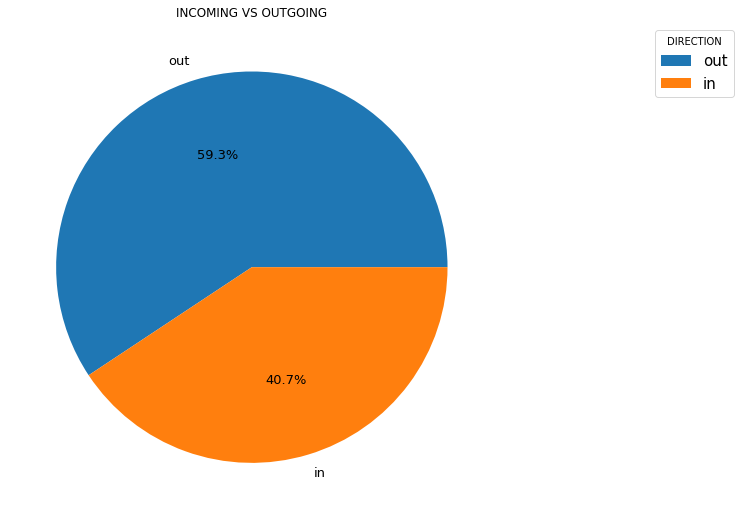

```python
# Slicing the data by direction
in_out_calls = data['direction'].value_counts().to_dict()

# Plotting a pie chart
fig = plt.figure(figsize=(20,9))
ax = fig.add_subplot()
ax.pie(in_out_calls.values(),
    labels = in_out_calls.keys(),
    autopct = '%1.1f%%',
    textprops = {'fontsize' : 13, 'color': 'black'}
    )
ax.set_title('INCOMING VS OUTGOING')
ax.legend(loc = 'upper right', bbox_to_anchor = (1, 0, 0.5, 1), fontsize = 15, title= "DIRECTION");
```

- We can see that most of the calls are outgoing (59.3%) compare to incoming calls (40.7%).
- I'm assuming most the opreators' job is to call users/clients - by that we can definitely say that a small number of outgoing calls is indeed ineffectiveness.

#### Now let's check the conversion of missed incoming and outgoing calls:

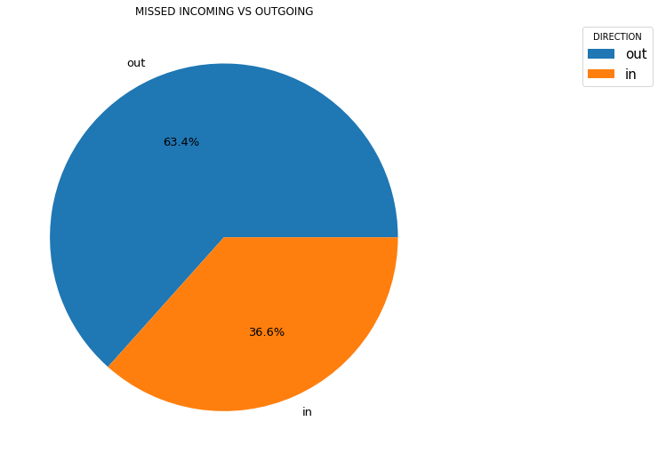

```python
# Slicing the data by missed calls and direction
missed_calls = data.query('is_missed_call == True')
missed_calls_dir = missed_calls['direction'].value_counts().to_dict()

# Plotting a pie chart
fig = plt.figure(figsize=(20,9))
ax = fig.add_subplot()
ax.pie(missed_calls_dir.values(),
    labels = missed_calls_dir.keys(),
    autopct = '%1.1f%%',
    textprops = {'fontsize' : 13, 'color': 'black'}
    )
ax.set_title('MISSED INCOMING VS OUTGOING')
ax.legend(loc = 'upper right', bbox_to_anchor = (1, 0, 0.5, 1), fontsize = 15, title= "DIRECTION");
```

- As we can see there are more outgoing missed calls than incoming missed calls. This shows in general a good effectivness.
- The operator is trying to get in touch with the user/clients more than the client is trying to reach for the operator/company.
- By that, when we will investigate ineffectivness by missed calls, we need to exclude outgoing missed calls as a part of the parameter, cause that actually shows that the operator is trying to get in touch with the client, which it's most of his job, nased on the pie graph of "incoming vs outgoing" pie graph.
- Although I'm excluding the outgoing missed calls, It's better to check in which hours the operators call to reduce the amount of outgoing missed calls, but for now let's exclude those calls when we investigate the opreators missed calls number.

#### Now I will start investigating what is the number of missed calls that considered the operator to be ineffective:

#### My method: In the next steps I will take a look at th number of incoming missed calls compare to the total incoming calls of every operator to determine eventually what is the conversion of missed calls that shows of a ineffective operator.

#### First I'll look at incoming calls only:

```python
# Slicing the data using query
in_calls = data.query('direction == "in"')
in_calls #test
```

|  | user_id | date | direction | internal | operator_id | is_missed_call | calls_count | call_duration | total_call_duration |
| --- | --- | --- | --- | --- | --- | --- | --- | --- | --- |
| 0 | 166377 | 2019-08-03 21:00:00 | in | False | 0 | True | 2 | 0 | 4 |
| 7 | 166377 | 2019-08-04 21:00:00 | in | False | 0 | True | 6 | 0 | 35 |
| 9 | 166377 | 2019-08-05 21:00:00 | in | False | 0 | True | 4 | 0 | 62 |
| 17 | 166377 | 2019-08-06 21:00:00 | in | False | 0 | True | 2 | 0 | 24 |
| 26 | 166377 | 2019-08-11 21:00:00 | in | False | 880028 | False | 1 | 407 | 411 |
| ... | ... | ... | ... | ... | ... | ... | ... | ... | ... |
| 53889 | 168603 | 2019-11-27 21:00:00 | in | False | 0 | True | 1 | 0 | 30 |
| 53891 | 168606 | 2019-11-07 21:00:00 | in | False | 957922 | True | 1 | 0 | 7 |
| 53893 | 168606 | 2019-11-07 21:00:00 | in | False | 0 | True | 6 | 0 | 121 |
| 53894 | 168606 | 2019-11-07 21:00:00 | in | False | 957922 | False | 2 | 686 | 705 |
| 53901 | 168606 | 2019-11-18 21:00:00 | in | False | 0 | True | 2 | 0 | 64 |

19895 rows × 9 columns

#### Now I want to create a function that counts the number of missed calls for every attempt to contact the operator. For example if it wasn't a missed call but there were 5 attempts till the operator answered then the number of missed_count is 4 and if the call was eventually missed call and the client tried to reach out for 3 times than the missed_count is 3.

```python
# Creating a function to count missed calls
def missed_calls_count(row):
    miss = row['is_missed_call']
    count = row['calls_count']
    if miss == True:
        return count
    else:
        return count - 1

# Applying the function to the dataset by creating a new column that will store the values
in_calls['missed_count'] = in_calls.apply(missed_calls_count, axis = 1)
in_calls.head() #test
```

|  | user_id | date | direction | internal | operator_id | is_missed_call | calls_count | call_duration | total_call_duration | missed_count |
| --- | --- | --- | --- | --- | --- | --- | --- | --- | --- | --- |
| 0 | 166377 | 2019-08-03 21:00:00 | in | False | 0 | True | 2 | 0 | 4 | 2 |
| 7 | 166377 | 2019-08-04 21:00:00 | in | False | 0 | True | 6 | 0 | 35 | 6 |
| 9 | 166377 | 2019-08-05 21:00:00 | in | False | 0 | True | 4 | 0 | 62 | 4 |
| 17 | 166377 | 2019-08-06 21:00:00 | in | False | 0 | True | 2 | 0 | 24 | 2 |
| 26 | 166377 | 2019-08-11 21:00:00 | in | False | 880028 | False | 1 | 407 | 411 | 0 |

```python
missed_conversion = in_calls.groupby('operator_id').agg({'calls_count':'sum','missed_count':'sum'})
missed_conversion['missed_conversion(%)'] = missed_conversion['missed_count']/missed_conversion['calls_count']*100
missed_conversion.columns = ['all_incalls', 'missed_calls', 'missed_conversion(%)']
missed_conversion
```

| operator_id | all_incalls | missed_calls | missed_conversion(%) |
| --- | --- | --- | --- |
| 0 | 103884 | 103816 | 99.934542 |
| 879896 | 58 | 37 | 63.793103 |
| 879898 | 103 | 47 | 45.631068 |
| 880020 | 7 | 0 | 0.000000 |
| 880022 | 8 | 0 | 0.000000 |
| ... | ... | ... | ... |
| 971102 | 76 | 72 | 94.736842 |
| 971354 | 6 | 4 | 66.666667 |
| 972412 | 1 | 0 | 0.000000 |
| 972460 | 1 | 0 | 0.000000 |
| 973286 | 2 | 1 | 50.000000 |

755 rows × 3 columns

**I've noticed a few things:**

1. the group of unknown operators that I signed with 0 has the worst conversion rate with almost 100% of missed calls out of the total incoming calls. I'm starting to think that these are operators that got fired quickly cause there were very bad at their job that the company didn't even assigned them with an operator ID, or that these calls are calls that came to a trainee and therefore, he/she wasn't allowed to answer the calls by themselves. either way, I have to show these calls/unkonwn operators to the engineers.
2. We can see that there are operators that are doing a great job and have 0 missed calls, that means that it is possible to answer all calls.
3. Based on the number of rows in this dataset, I can see that out of 1093 unique operators (based on my first exploration of the data) there are only 755. which means that there are operators that their job is only to make calls, which means they have only outgoing calls.
4. I start from a premise where I don't know what is a good operator, a good employee, when it comes to the specific number/conversion of missed calls. Maybe 50% conversion is legitimate based on the company or in general. Therefore, I'm relying on the cpnversion rates among the operators that are inside the data. the company didn't provide me with additional information, and I'm sure it changes between companies and clients.

**Based on my last conclusion (#4), I will create a distribution graph that will display the conversion rate among the operators,I will search for outliers around the higher conversion rates, use the describe method and qcut and eventually determine what is a ineffective operator based on missed valls conversion groups.**

```python
# Plotting distribution graph of coversion rates using plotly
fig = px.histogram(missed_conversion, x='missed_conversion(%)', title='Distribution Of Missed Calls Conversion Rate')
fig.show()
```

[interactive chart not shown]

- Based on the graph we can already see the group that has the lowest conversion rate - around the 0-2.5%. as it looks there are a lot of good operators, 158 operators out of 755 with 0-2.5% conversio rate.
- We see that the operators that around the 100% will be the most ineffictive ones.
- Around the 40-52 conversion rate we can see a lot of operators.
- However let's use the **describe method** to dig into it.

```python
missed_conversion.describe()
```

|  | all_incalls | missed_calls | missed_conversion(%) |
| --- | --- | --- | --- |
| count | 755.000000 | 755.000000 | 755.000000 |
| mean | 261.756291 | 245.780132 | 45.366897 |
| std | 3792.950348 | 3790.164888 | 32.091157 |
| min | 1.000000 | 0.000000 | 0.000000 |
| 25% | 4.000000 | 1.000000 | 18.181818 |
| 50% | 17.000000 | 7.000000 | 46.153846 |
| 75% | 79.000000 | 55.000000 | 72.925647 |
| max | 103884.000000 | 103816.000000 | 100.000000 |

**Based on the describe method I've noticed a few things:**

- While looking at the calls_count and missed_count we can see that the max values are very high and the std is also very high as well as the differences between the median and the mean value. which means that there are some operators that have a lot of pressure/load/work on them compare to others or they're might be taking more working hours, etc.
- While looking at the missed conversion column, we can see that the mean and median value are pretty close to each other, which means there aren't extreme outliers affecting the mean. we can see that based on the Q's, we can split the operators to 4 groups based on their conversion missed calls:
  - Group 1: 0-18% conversion rate
  - Group 2: 19-46% conversion rate
  - Group 3: 47-73% conversion rate
  - Group 4: 74-100% conversion rate

**I would like to use the qcut method to assign these group based on their missed calls converion rate into 4 groups in the range from 1-4: where 1 is the least effective operator and 4 is the most effective operator**

```python
# Using qcut to score the operators
missed_conversion['missed_score'] = pd.qcut(missed_conversion['missed_conversion(%)'], q=4, labels=[4, 3, 2, 1])
missed_conversion #test
```

| operator_id | all_incalls | missed_calls | missed_conversion(%) | missed_score |
| --- | --- | --- | --- | --- |
| 0 | 103884 | 103816 | 99.934542 | 1 |
| 879896 | 58 | 37 | 63.793103 | 2 |
| 879898 | 103 | 47 | 45.631068 | 3 |
| 880020 | 7 | 0 | 0.000000 | 4 |
| 880022 | 8 | 0 | 0.000000 | 4 |
| ... | ... | ... | ... | ... |
| 971102 | 76 | 72 | 94.736842 | 1 |
| 971354 | 6 | 4 | 66.666667 | 2 |
| 972412 | 1 | 0 | 0.000000 | 4 |
| 972460 | 1 | 0 | 0.000000 | 4 |
| 973286 | 2 | 1 | 50.000000 | 2 |

755 rows × 4 columns

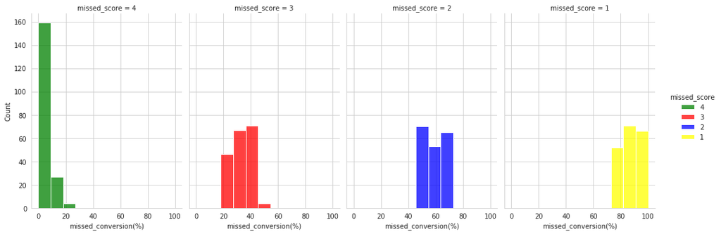

```python
# Plotting a graph of conversion rate for every group (score)
sns.set_style("whitegrid")
sns.displot(missed_conversion, x='missed_conversion(%)', col="missed_score",hue='missed_score',height=5, aspect=0.7,palette=["green", "red", "blue",'yellow'])
plt.show()
```

**We can see how the conversion rate distributed in every score, we can also see the high column of the 4 score group with exceptional conversion rates. The yellow distribution of score 1 is the problematic one for the company.**

**Towards the end I will merge the 3 parameters scores based on the operator ID, so for now let's continue to the next parameter:**

### Waiting time:

Go back to the Table of Contents

**Here in order to check only the waiting time I will create a new column that stores the waiting time by subtracting `total_call_duration`(call duration including waiting time) - `call_duration`(call duration excluding waiting time)**

```python
data['waiting_time'] = data['total_call_duration'] - data['call_duration']
data.head() #test
```

|  | user_id | date | direction | internal | operator_id | is_missed_call | calls_count | call_duration | total_call_duration | waiting_time |
| --- | --- | --- | --- | --- | --- | --- | --- | --- | --- | --- |
| 0 | 166377 | 2019-08-03 21:00:00 | in | False | 0 | True | 2 | 0 | 4 | 4 |
| 1 | 166377 | 2019-08-04 21:00:00 | out | True | 880022 | True | 3 | 0 | 5 | 5 |
| 2 | 166377 | 2019-08-04 21:00:00 | out | True | 880020 | True | 1 | 0 | 1 | 1 |
| 3 | 166377 | 2019-08-04 21:00:00 | out | True | 880020 | False | 1 | 10 | 18 | 8 |
| 4 | 166377 | 2019-08-04 21:00:00 | out | False | 880022 | True | 3 | 0 | 25 | 25 |

```python
# Checking to see if there are negative waiting time (peculiarities)
data.loc[data['waiting_time'] < 0]
```

|  | user_id | date | direction | internal | operator_id | is_missed_call | calls_count | call_duration | total_call_duration | waiting_time |
| --- | --- | --- | --- | --- | --- | --- | --- | --- | --- | --- |

**All clear**

**Since the operators have different dates and amount of calls I will use the average waiitng time as a parameter:**

**Now let's group the data by operator Id and take a look at the distribution of waiting time as well as the metrics using describe method:**

```python
# Grouping by operator id and calculationg the average waiting time
waiting_data = data.groupby('operator_id').agg({'waiting_time':'mean'})
waiting_data.columns = ['avg_waiting_time']
waiting_data.head()
```

| operator_id | avg_waiting_time |
| --- | --- |
| 0 | 171.333739 |
| 879896 | 104.914530 |
| 879898 | 459.690265 |
| 880020 | 14.000000 |
| 880022 | 53.971429 |

```python
# Using lambda function to display the numbers in a more readable way
waiting_data.describe().apply(lambda s: s.apply(lambda x: format(x, 'g')))
```

|  | avg_waiting_time |
| --- | --- |
| count | 1093 |
| mean | 216.209 |
| std | 506.822 |
| min | 0 |
| 25% | 23 |
| 50% | 46.6667 |
| 75% | 161.286 |
| max | 5805.03 |

- Here we can see that the median and mean values are far from being similar/close to each other. with a max value of 5805 and a high std of 506. we can already tell that the distribution will show a lot of outliers towards the higher values of the graph.
- This maximun value is a lot and totally seems to be unreasonable. I'm assuming this is an error or a problem that doesn't reflect reality and shouldn't be considered as waiting time.
- Having said that, I will plot a boxplot graph to display the distribution of waiting time and decide from which values it seems unreasonable and later will filter the data in order to get more accurate results.

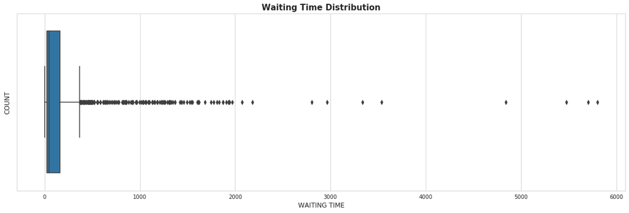

```python
# Plotting a boxplot graph for waiting time using seaborn
sns.set_style("whitegrid")
fig,ax=plt.subplots(figsize=(20,6))
ax = sns.boxplot(x=waiting_data['avg_waiting_time'])
ax.set_title("Waiting Time Distribution", fontsize=15, fontweight="bold")
ax.set_xlabel('WAITING TIME', fontsize=12)
ax.set_ylabel('COUNT', fontsize=12)
plt.show()
```

- As we can see, by using the boxplot, there are a lot of outliers around that is the 75%-100% area. that explains the high std and the differences between the median and mean values we saw with the describe method.
- I will also contact the engineers to inform them about this error/peculiarities. during this whole process of analysing the data I come across more and more mess and peculiarities that won't let me trust the data 100% that is something worth mentioning at the end of my analysis to the comapny and the engineers. but for now let's continue.
- based on the boxplot and the describe method and the fact that there are a lot of outliers I will use the qcut again in order to split into 4 groups by scoring their waiting time ffrom 1-4 just like I did with the conversion rate.

**Let's split the data into 4 Qs and numbered them to 1-4:**

```python
# Using qcut to label the operators
waiting_data['waiting_score'] = pd.qcut(waiting_data['avg_waiting_time'], q=4, labels=[4, 3, 2, 1])
waiting_data #test
```

| operator_id | avg_waiting_time | waiting_score |
| --- | --- | --- |
| 0 | 171.333739 | 1 |
| 879896 | 104.914530 | 2 |
| 879898 | 459.690265 | 1 |
| 880020 | 14.000000 | 4 |
| 880022 | 53.971429 | 2 |
| ... | ... | ... |
| 972410 | 374.500000 | 1 |
| 972412 | 210.000000 | 1 |
| 972460 | 88.571429 | 2 |
| 973120 | 10.000000 | 4 |
| 973286 | 88.000000 | 2 |

1093 rows × 2 columns

**Now I will investigate the last parameter:**

### Number of outgoing calls:

Go back to the Table of Contents

**In order to investigate the number of outgoing calls, I will first need to slice the data:**

```python
# Slicing the data using query
out_calls = data.query('direction == "out"')
out_calls #test
```

|  | user_id | date | direction | internal | operator_id | is_missed_call | calls_count | call_duration | total_call_duration | waiting_time |
| --- | --- | --- | --- | --- | --- | --- | --- | --- | --- | --- |
| 1 | 166377 | 2019-08-04 21:00:00 | out | True | 880022 | True | 3 | 0 | 5 | 5 |
| 2 | 166377 | 2019-08-04 21:00:00 | out | True | 880020 | True | 1 | 0 | 1 | 1 |
| 3 | 166377 | 2019-08-04 21:00:00 | out | True | 880020 | False | 1 | 10 | 18 | 8 |
| 4 | 166377 | 2019-08-04 21:00:00 | out | False | 880022 | True | 3 | 0 | 25 | 25 |
| 5 | 166377 | 2019-08-04 21:00:00 | out | False | 880020 | False | 2 | 3 | 29 | 26 |
| ... | ... | ... | ... | ... | ... | ... | ... | ... | ... | ... |
| 53895 | 168606 | 2019-11-08 21:00:00 | out | False | 957922 | False | 4 | 551 | 593 | 42 |
| 53896 | 168606 | 2019-11-09 21:00:00 | out | True | 957922 | False | 1 | 0 | 25 | 25 |
| 53897 | 168606 | 2019-11-09 21:00:00 | out | True | 957922 | True | 1 | 0 | 38 | 38 |
| 53898 | 168606 | 2019-11-10 21:00:00 | out | True | 957922 | False | 2 | 479 | 501 | 22 |
| 53899 | 168606 | 2019-11-14 21:00:00 | out | True | 957922 | False | 4 | 3130 | 3190 | 60 |

28997 rows × 10 columns

**Let's group the data by the operator_id and count the number of calls:**

```python
# Grouping by operator id
outcalls_data = out_calls.groupby('operator_id').agg({'calls_count':'sum'})
outcalls_data.columns = ['outgoing_calls']
outcalls_data.reset_index()
```

|  | operator_id | outgoing_calls |
| --- | --- | --- |
| 0 | 0 | 515 |
| 1 | 879896 | 872 |
| 2 | 879898 | 7209 |
| 3 | 880020 | 38 |
| 4 | 880022 | 189 |
| ... | ... | ... |
| 878 | 972408 | 6 |
| 879 | 972410 | 77 |
| 880 | 972412 | 60 |
| 881 | 972460 | 50 |
| 882 | 973120 | 3 |

883 rows × 2 columns

- As we can see, as oppose to the incoming calls, there are more operators that perform outgoing calls (883 compare to 755).

**Let's use the describe method to see what is considered a small number of outgoing calls:**

```python
outcalls_data.describe()
```

|  | outgoing_calls |
| --- | --- |
| count | 883.000000 |
| mean | 689.533409 |
| std | 3121.188601 |
| min | 1.000000 |
| 25% | 11.000000 |
| 50% | 90.000000 |
| 75% | 591.500000 |
| max | 58977.000000 |

**Based on the describe method, we can see a few things:**

- The number of unique operators that perform outgoing calls is 883.
- The max number of outgoing calls per operator is 58977 which is a lot.
- The min is 1.
- The mean value is 689.5 and the median is 90 with 3121.19. which means there are outliers that are a operators with an extreme amount of outgoing calls. I'm sure if that is an error or just an operator with a lot of work/load. but I will still forward it to the engineers to see if that's reasonable or not.

**Let's take a look at a distribution of these outgoing calls: (BOXPLOT AND HISTOGRAM)**

```python
# Plotting distribution graph of outgoing calls using plotly
fig = px.histogram(outcalls_data, x='outgoing_calls', title='Distribution Of Outgoing Calls')
fig.show()
```

[interactive chart not shown]

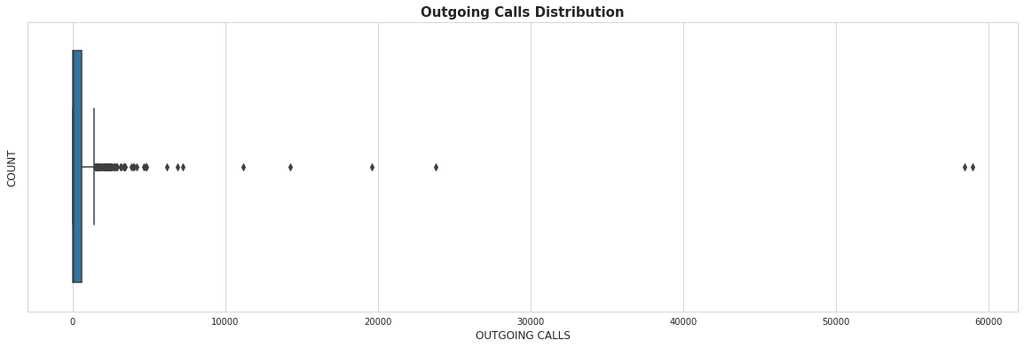

```python
# Plotting a boxplot graph for outgoing calls using seaborn
sns.set_style("whitegrid")
fig,ax=plt.subplots(figsize=(20,6))
ax = sns.boxplot(x=outcalls_data['outgoing_calls'])
ax.set_title("Outgoing Calls Distribution", fontsize=15, fontweight="bold")
ax.set_xlabel('OUTGOING CALLS', fontsize=12)
ax.set_ylabel('COUNT', fontsize=12)
plt.show()
```

- As we can see, both the describe method and the graphs show us that there are a lot of outliers, especially after crossing 5000 value.
- Most of the outgoing calls though, are around 1-499.
- Based on these findings I think that once againg the best way to assigned number of outgoing calls scores is by **using the qcut method**.

```python
# Using qcut to label the operators by score
outcalls_data['outgoing_score'] = pd.qcut(outcalls_data['outgoing_calls'], q=4, labels=[4, 3, 2, 1])
outcalls_data #test
```

| operator_id | outgoing_calls | outgoing_score |
| --- | --- | --- |
| 0 | 515 | 2 |
| 879896 | 872 | 1 |
| 879898 | 7209 | 1 |
| 880020 | 38 | 3 |
| 880022 | 189 | 2 |
| ... | ... | ... |
| 972408 | 6 | 4 |
| 972410 | 77 | 3 |
| 972412 | 60 | 3 |
| 972460 | 50 | 3 |
| 973120 | 3 | 4 |

883 rows × 2 columns

## Now, after investigating all three parameters and dividing them into 4 scores - where 1 is the least effective operator and 4 is the most effective operator. I'll create a dataset with the operator ID and its 3 scores, and then create a function to check for ineffective operators.

Go back to the Table of Contents

### But first let's merge all 3 datasets that contain the scores of 3 parameters:

**There are missing values in some datasets scores due to the fact that there are operators that only perform outgoing calls or vice verse (incoming calls). Therefore, I will fill them with 4 which is the highest number cause I can't evaluate somethig they don't do.**

```python
# using merge method to join all datasets based on operator_id
waiting_outgoing = pd.merge(left=waiting_data,right=outcalls_data,how='outer',on='operator_id').fillna(4)
waiting_outgoing

all_scores = pd.merge(left=waiting_outgoing,right=missed_conversion,how='outer',on='operator_id').fillna(4)
all_scores
```

| operator_id | avg_waiting_time | waiting_score | outgoing_calls | outgoing_score | all_incalls | missed_calls | missed_conversion(%) | missed_score |
| --- | --- | --- | --- | --- | --- | --- | --- | --- |
| 0 | 171.333739 | 1 | 515.0 | 2 | 103884.0 | 103816.0 | 99.934542 | 1 |
| 879896 | 104.914530 | 2 | 872.0 | 1 | 58.0 | 37.0 | 63.793103 | 2 |
| 879898 | 459.690265 | 1 | 7209.0 | 1 | 103.0 | 47.0 | 45.631068 | 3 |
| 880020 | 14.000000 | 4 | 38.0 | 3 | 7.0 | 0.0 | 0.000000 | 4 |
| 880022 | 53.971429 | 2 | 189.0 | 2 | 8.0 | 0.0 | 0.000000 | 4 |
| ... | ... | ... | ... | ... | ... | ... | ... | ... |
| 972410 | 374.500000 | 1 | 77.0 | 3 | 4.0 | 4.0 | 4.000000 | 4 |
| 972412 | 210.000000 | 1 | 60.0 | 3 | 1.0 | 0.0 | 0.000000 | 4 |
| 972460 | 88.571429 | 2 | 50.0 | 3 | 1.0 | 0.0 | 0.000000 | 4 |
| 973120 | 10.000000 | 4 | 3.0 | 4 | 4.0 | 4.0 | 4.000000 | 4 |
| 973286 | 88.000000 | 2 | 4.0 | 4 | 2.0 | 1.0 | 50.000000 | 2 |

1093 rows × 8 columns

```python
all_scores.info()
```

```
<class 'pandas.core.frame.DataFrame'>
Int64Index: 1093 entries, 0 to 973286
Data columns (total 8 columns):
avg_waiting_time        1093 non-null float64
waiting_score           1093 non-null category
outgoing_calls          1093 non-null float64
outgoing_score          1093 non-null category
all_incalls             1093 non-null float64
missed_calls            1093 non-null float64
missed_conversion(%)    1093 non-null float64
missed_score            1093 non-null category
dtypes: category(3), float64(5)
memory usage: 55.0 KB
```

**We can see that the scores were saved as category type and in order to calculate the final score I need to convert them into int type:**

```python
# Converting using astype method
all_scores['waiting_score'] = all_scores['waiting_score'].astype('int')
all_scores['outgoing_score'] = all_scores['outgoing_score'].astype('int')
all_scores['missed_score'] = all_scores['missed_score'].astype('int')
```

**Now I will calculate the mean score of every operator and then assign a group/level of effectivness to it:**

```python
all_scores['final_score'] = ((all_scores['waiting_score'] + all_scores['outgoing_score'] + all_scores['missed_score'])/3).round(1)
all_scores.reset_index()
```

|  | operator_id | avg_waiting_time | waiting_score | outgoing_calls | outgoing_score | all_incalls | missed_calls | missed_conversion(%) | missed_score | final_score |
| --- | --- | --- | --- | --- | --- | --- | --- | --- | --- | --- |
| 0 | 0 | 171.333739 | 1 | 515.0 | 2 | 103884.0 | 103816.0 | 99.934542 | 1 | 1.3 |
| 1 | 879896 | 104.914530 | 2 | 872.0 | 1 | 58.0 | 37.0 | 63.793103 | 2 | 1.7 |
| 2 | 879898 | 459.690265 | 1 | 7209.0 | 1 | 103.0 | 47.0 | 45.631068 | 3 | 1.7 |
| 3 | 880020 | 14.000000 | 4 | 38.0 | 3 | 7.0 | 0.0 | 0.000000 | 4 | 3.7 |
| 4 | 880022 | 53.971429 | 2 | 189.0 | 2 | 8.0 | 0.0 | 0.000000 | 4 | 2.7 |
| ... | ... | ... | ... | ... | ... | ... | ... | ... | ... | ... |
| 1088 | 972410 | 374.500000 | 1 | 77.0 | 3 | 4.0 | 4.0 | 4.000000 | 4 | 2.7 |
| 1089 | 972412 | 210.000000 | 1 | 60.0 | 3 | 1.0 | 0.0 | 0.000000 | 4 | 2.7 |
| 1090 | 972460 | 88.571429 | 2 | 50.0 | 3 | 1.0 | 0.0 | 0.000000 | 4 | 3.0 |
| 1091 | 973120 | 10.000000 | 4 | 3.0 | 4 | 4.0 | 4.0 | 4.000000 | 4 | 4.0 |
| 1092 | 973286 | 88.000000 | 2 | 4.0 | 4 | 2.0 | 1.0 | 50.000000 | 2 | 2.7 |

1093 rows × 10 columns

**Finally I will create a function that divides the operators to groups of effectivness based on their mean score:**

```python
# Creating a function that creates operators groups
def group_operators(score):
    if score == 4:
        return "Best Operator"
    elif 3.0 <= score <= 3.9:
        return "Great Operator"
    elif 2.0 <= score <= 2.9:
        return "OK Operator"
    elif 1.0 <= score <= 1.9:
        return "Bad Operator"
    else:
        return "Other"
# Applying the function to the dataset and creating a new column to store the group value
all_scores['group'] = all_scores['final_score'].apply(group_operators)
all_scores = all_scores.reset_index()
all_scores
```

[output not shown]

1093 rows × 11 columns

```python
# grouping by group and counting the number of operators for each
all_scores_bar = all_scores.groupby('group').agg({'operator_id':'count'})
all_scores_bar = all_scores_bar.sort_values('operator_id',ascending= False).reset_index()
all_scores_bar
```

|  | group | operator_id |
| --- | --- | --- |
| 0 | OK Operator | 393 |
| 1 | Great Operator | 377 |
| 2 | Bad Operator | 165 |
| 3 | Best Operator | 158 |

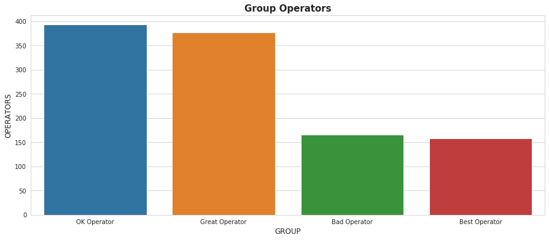

```python
# Plotting a bar graph to display the number of operators for each group
sns.set_style("whitegrid")

fig,ax=plt.subplots(figsize=(15,6))

sns.barplot(x="group", y="operator_id", data=all_scores_bar)

ax.set_title("Group Operators", fontsize=15, fontweight="bold")
ax.set_xlabel('GROUP', fontsize=12)
ax.set_ylabel('OPERATORS', fontsize=12)
plt.show()
```

## Step 4 - Testing Hypotheses:

Go back to the Table of Contents

**After dividing the operators for groups (best, great, good and bad) I want to check if there's a significant difference in the parameters between the bad group and the other grorups (better ones). In other words I wanna test how bad are the bad operators compare to the other operators that are above average, that way I can also test if my method to identify bad operators is really efficient**

#### Null Hypothesis: There isn't a statistical significant difference in average waiting time between bad operators and the rest of the operators

#### Alternative Hypothesis: There is a statistical significant difference in average waiting time between bad operators and the rest of the operators.

**First I will slice the dataset to bad operators and the rest:**

```python
# Using query to slice bad operators and the rest

bad_operators = all_scores.query('group == "Bad Operator"')
rest_operators = all_scores.query('group != "Bad Operator"')
```

**After I sliced the dataset, I want to see which test will be the best to use based on the samples that I have, therefore I will find the number of operators for each group and use the describe method to analyse the distribution:**

```python
# Using shape method to see how many operators in every sample
print(bad_operators.shape)
rest_operators.shape
```

```
(165, 11)
```

```
(928, 11)
```

```python
# Creating variables to store the average waiting time for each group
bad_operators_waiting = bad_operators['avg_waiting_time']
rest_operators_waiting = rest_operators['avg_waiting_time']
```

```python
# using describe method
bad_operators.describe()
```

|  | operator_id | avg_waiting_time | waiting_score | outgoing_calls | outgoing_score | all_incalls | missed_calls | missed_conversion(%) | missed_score | final_score |
| --- | --- | --- | --- | --- | --- | --- | --- | --- | --- | --- |
| count | 165.000000 | 165.000000 | 165.000000 | 165.000000 | 165.000000 | 165.000000 | 165.000000 | 165.000000 | 165.000000 | 165.000000 |
| mean | 916219.103030 | 334.525505 | 1.381818 | 1815.539394 | 1.448485 | 1046.187879 | 1012.775758 | 79.530151 | 1.309091 | 1.384848 |
| std | 75165.289136 | 720.209484 | 0.487311 | 6557.979884 | 0.578118 | 8079.962662 | 8076.451566 | 18.039837 | 0.611058 | 0.297265 |
| min | 0.000000 | 51.232000 | 1.000000 | 20.000000 | 1.000000 | 1.000000 | 1.000000 | 21.428571 | 1.000000 | 1.000000 |
| 25% | 902720.000000 | 125.050251 | 1.000000 | 301.000000 | 1.000000 | 67.000000 | 47.000000 | 74.566474 | 1.000000 | 1.000000 |
| 50% | 921320.000000 | 191.934783 | 1.000000 | 751.000000 | 1.000000 | 192.000000 | 158.000000 | 84.897959 | 1.000000 | 1.300000 |
| 75% | 939474.000000 | 331.507937 | 2.000000 | 1397.000000 | 2.000000 | 501.000000 | 443.000000 | 92.641129 | 1.000000 | 1.700000 |
| max | 969272.000000 | 5805.027397 | 2.000000 | 58977.000000 | 3.000000 | 103884.000000 | 103816.000000 | 100.000000 | 3.000000 | 1.700000 |

```python
rest_operators.describe()
```

|  | operator_id | avg_waiting_time | waiting_score | outgoing_calls | outgoing_score | all_incalls | missed_calls | missed_conversion(%) | missed_score | final_score |
| --- | --- | --- | --- | --- | --- | --- | --- | --- | --- | --- |
| count | 928.000000 | 928.000000 | 928.000000 | 928.000000 | 928.000000 | 928.000000 | 928.000000 | 928.000000 | 928.000000 | 928.000000 |
| mean | 926173.497845 | 195.171883 | 2.701509 | 334.196121 | 3.028017 | 28.401940 | 21.344828 | 24.225789 | 3.259698 | 2.997845 |
| std | 22878.328557 | 455.948729 | 1.082527 | 1189.415188 | 1.081008 | 108.546189 | 103.101659 | 27.365040 | 0.972332 | 0.709084 |
| min | 880020.000000 | 0.000000 | 1.000000 | 1.000000 | 1.000000 | 1.000000 | 0.000000 | 0.000000 | 1.000000 | 2.000000 |
| 25% | 907177.000000 | 19.753623 | 2.000000 | 4.000000 | 2.000000 | 4.000000 | 2.000000 | 4.000000 | 3.000000 | 2.300000 |
| 50% | 926199.000000 | 36.167081 | 3.000000 | 15.500000 | 3.000000 | 4.000000 | 4.000000 | 4.000000 | 4.000000 | 3.000000 |
| 75% | 945275.000000 | 87.746622 | 4.000000 | 172.500000 | 4.000000 | 16.000000 | 7.000000 | 45.454545 | 4.000000 | 3.700000 |
| max | 973286.000000 | 5478.123077 | 4.000000 | 23754.000000 | 4.000000 | 2127.000000 | 2090.000000 | 99.141631 | 4.000000 | 4.000000 |

**Let's return to our hypothesis:**

#### Null Hypothesis: There isn't a statistical significant difference in average waiting time between bad operators and the rest of the operators

#### Alternative Hypothesis: There is a statistical significant difference in average waiting time between bad operators and the rest of the operators.

**Now let's find if there's a statistical significant difference:**

```python
# Finding the statistical significance

alpha = 0.05 #significance level

# calculating the p-value
p_value = stats.mannwhitneyu(bad_operators_waiting, rest_operators_waiting)[1]

print("P VALUE: {0:.3f}".format(p_value))
if (p_value < alpha):
    print("Null hypothesis rejected: the difference is statistically significant")
else:
    print("Failed to reject the null hypothesis: we can't make conclusions about the difference")
```

[output not shown]

- The p value is 0 smaller than the alpha value.
- As we can see, the Null hypothesis rejected, the difference is statistically significant. the average waiting time differs between good and bad operators, this is good for us cause we can see that the scoring method works and the operators with the longest average time are bad for a reason.

**But about the conversion missed calls between bad and the rest of the operators:**

#### Null Hypothesis: There isn't a statistical significant difference in missed call conversion between bad operators and the rest of the operators

#### Alternative Hypothesis: There is a statistical significant difference in missed call conversion between bad operators and the rest of the operators.

```python
# Creating variables to store the missed call conversion for each group

bad_operators_conversion = bad_operators['missed_conversion(%)']
rest_operators_conversion = rest_operators['missed_conversion(%)']
```

```python
# Finding the statistical significance

alpha = 0.05 #significance level

# calculating the p-value
p_value = stats.mannwhitneyu(bad_operators_conversion, rest_operators_conversion)[1]

print("P VALUE: {0:.3f}".format(p_value))
if (p_value < alpha):
    print("Null hypothesis rejected: the difference is statistically significant")
else:
    print("Failed to reject the null hypothesis: we can't make conclusions about the difference")
```

```
P VALUE: 0.000
Null hypothesis rejected: the difference is statistically significant
```

- The p value is 0 smaller than the alpha value.
- As we can see, the Null hypothesis rejected, the difference is statistically significant. the conversion rate of missed calls differs between good and bad operators, this is good for us cause we can see that the scoring method works and the operators with the biggest conversion rate are bad for a reason.

#### Null Hypothesis: There isn't a statistical significant difference in outgoing calls between bad operators and the rest of the operators

#### Alternative Hypothesis: There is a statistical significant difference in outgoing calls between bad operators and the rest of the operators.

```python
# Creating variables to store the outgoing calls for each group
bad_operators_calls = bad_operators['outgoing_calls']
rest_operators_calls = rest_operators['outgoing_calls']
```

```python
# Finding the statistical significance

alpha = 0.05 #significance level

# calculating the p-value
p_value = stats.mannwhitneyu(bad_operators_calls, rest_operators_calls)[1]

print("P VALUE: {0:.3f}".format(p_value))
if (p_value < alpha):
    print("Null hypothesis rejected: the difference is statistically significant")
else:
    print("Failed to reject the null hypothesis: we can't make conclusions about the difference")
```

```
P VALUE: 0.000
Null hypothesis rejected: the difference is statistically significant
```

- The p value is 0 smaller than the alpha value.
- As we can see, the Null hypothesis rejected, the difference is statistically significant. the number of outgoing calls differs between good and bad operators, this is good for us cause we can see that the scoring method works and the operators with the lowest amount of outgoing calls are bad for a reason.

**Overall, based on the 3 hypotheses tests, we can be sure that there's a statistical significant difference in all parameters between bad operators and the better/rest of the operators.**

- P.S: I looked further than 3 places after the mark of p value and it is close to 0 but not 0.

## Final Conclusion and recommendation:

Go back to the Table of Contents

- After investigating the data, analyzing the parameters that defines the effectivness of the operatoprs, Here are my conclusions:
  - First and for most, based on the errors I've encountered during my analysis, i recommend to forward the data to the engineers, show them the peculiarities in the data (the long duration calls for example) and after fixing the errors I would suggest to re-analyze the data again.
  - We discovered that operator can be defined by 3 parameters - long waiting time, number of outgoing calls and conversion between missed incoming calls and incoming calls.
  - We also saw that these parameters are ranging widely thorughtout the distribution.
  - We have found that we can indeed seperate the operators to 4 groups based on their effectivness.
  - And then we tested to see if there is a significant differences between operators groups based on the parameters that we've chosen to judge/analyse them by.
  - I would reccommed the comapny to look for a better conversion rates in general, to shorten the waiting time, maybe some operators have more load and jobs than others, maje establish more operators. but mainly start with fixing the systematic errors.
- My goal was to identify ineffective operatros, I believe I've managed to do that, although I would like, like I said before to reanalyze the data after fixing a the bugs and also continue to identify more parameters that show ineffectivness in order to improve the results and the satisfaction of the clients.